# Practical Machine Learning Course Project

Salimah Mokhtar

December 23, 2015

## *Introduction*

This is the course project for Coursera Practical Machine Learning module. In this project, the goal will be to use data from accelerometers on the belt, forearm, arm, and dumbell of 6 participants. They were asked to perform one set of 10 repetitions of the Unilateral Dumbbell Biceps Curl in five different fashions:

- Class A - exactly according to the specification
- Class B - throwing the elbows to the front
- Class C - lifting the dumbbell only halfway
- Class D - lowering the dumbbell only halfway
- Class E - throwing the hips to the front.

Class A corresponds to the specified execution of the exercise, while the other 4 classes correspond to common mistakes.

The goal of the project is to predict the manner in which they did the exercise. This is the **“classe”** variable in the training set.

## *Data Sources*

The *training data* for this project are available here: https://d396qusza40orc.cloudfront.net/predmachlearn/pml-training.csv

The *test data* are available here: https://d396qusza40orc.cloudfront.net/predmachlearn/pml-testing.csv

The data for this project come from this source: http://groupware.les.inf.puc-rio.br/har.

The link to the *github repository* containing the .Rmd or .md file and the compiled HTML file performing the analysis is as follows: http://SalimahM.github.io/practicalmachinelearning/

## *Loading Libraries*

Load Required Libraries and set a seed for reproduceablity.

```r
library (caret)
library (randomForest)
set.seed(3141592)
```

## *Getting the Data*

The training and testing data set is downloaded and then stored the dataset at “/Users/salimahmokhtar”.

```r
training <- read.csv(file="pml-training.csv", head=TRUE,sep=",", na.strings=c("NA" , "#DIV/0!"))
testing <- read.csv(file="pml-testing.csv", head=TRUE,sep=",")
```

We take a quick look at the data and particularly at **classe** which is the variable we need to predict.

```r
str(training, list.len=15)
```

```
## 'data.frame':    19622 obs. of  160 variables:
##  $ X                       : int  1 2 3 4 5 6 7 8 9 10 ...
##  $ user_name               : Factor w/ 6 levels "adelmo","carlitos",..: 2 2 2 2 2 2 2 2 2 2 ...
##  $ raw_timestamp_part_1    : int  1323084231 1323084231 1323084231 1323084232 1323084232 1323084232 1323084232 1323084232 1323084232 1323084232 ...
##  $ raw_timestamp_part_2    : int  788290 808298 820366 120339 196328 304277 368296 440390 484323 484434 ...
##  $ cvtd_timestamp          : Factor w/ 20 levels "02/12/2011 13:32",..: 9 9 9 9 9 9 9 9 9 9 ...
##  $ new_window              : Factor w/ 2 levels "no","yes": 1 1 1 1 1 1 1 1 1 1 ...
##  $ num_window              : int  11 11 11 12 12 12 12 12 12 12 ...
##  $ roll_belt               : num  1.41 1.41 1.42 1.48 1.48 1.45 1.42 1.42 1.43 1.45 ...
##  $ pitch_belt              : num  8.07 8.07 8.07 8.05 8.07 8.06 8.09 8.13 8.16 8.17 ...
##  $ yaw_belt                : num  -94.4 -94.4 -94.4 -94.4 -94.4 -94.4 -94.4 -94.4 -94.4 -94.4 ...
##  $ total_accel_belt        : int  3 3 3 3 3 3 3 3 3 3 ...
##  $ kurtosis_roll_belt      : num  NA NA NA NA NA NA NA NA NA NA ...
##  $ kurtosis_picth_belt     : num  NA NA NA NA NA NA NA NA NA NA ...
##  $ kurtosis_yaw_belt       : logi  NA NA NA NA NA NA ...
##  $ skewness_roll_belt      : num  NA NA NA NA NA NA NA NA NA NA ...
##   [list output truncated]
```

```r
table(training$classe)
```

```
##
##    A    B    C    D    E
## 5580 3797 3422 3216 3607
```

## *Cleaning the Data*

Based on the above information, first do some basic data clean-up by removing columns 1 to 6, which are there just for information and reference purposes.

```r
training <- training[, 7:160]
testing  <- testing[, 7:160]
```

Removing all columns that are mostly NA:

```r
is_data  <- apply(!is.na(training), 2, sum) > 19621  # which is the number of observations
training <- training[, is_data]
testing  <- testing[, is_data]
```

## *Partitioning the training data set into two parts*.

The training set is split into two for cross validation purposes. 60% for myTraining and 40% for myTesting

```r
inTrain <- createDataPartition(y=training$classe, p=0.6, list=FALSE)
myTraining <- training[inTrain, ]; myTesting <- training[-inTrain, ]
dim(myTraining); dim(myTesting)
```

```
## [1] 11776    54
```

```
## [1] 7846   54
```

myTraining is the training data set which contains *11776 observations*, or about *60%* of the entire training data set, and myTesting is the testing data set that contains *7846 observations*, or about *40%* of the entire training data set.

Now, we can identify the **zero covariates** from myTraining and remove these **zero covariates** from both myTraining and myTesting.

```r
nzv_cols <- nearZeroVar(myTraining)
if(length(nzv_cols) > 0) {
  myTraining <- myTraining[, -nzv_cols]
  myTesting <- myTesting[, -nzv_cols]
}
dim(myTraining)
```

```
## [1] 11776    54
```

```r
dim(myTesting)
```

```
## [1] 7846   54
```

## *Evaluating Algorithm*

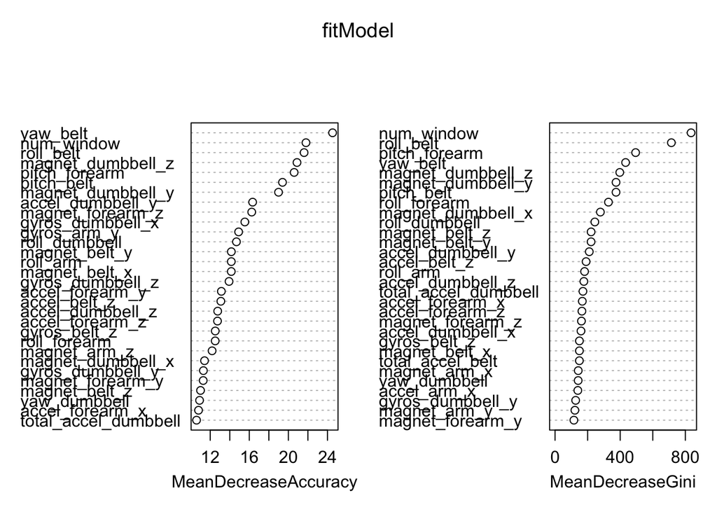

```r
fitModel <- randomForest(classe~., data=myTraining, importance=TRUE, ntree=100)
varImpPlot(fitModel)
```

Using the Accuracy and Gini graphs above, we select the top 10 variables that will be used for model building. If the accuracy of the resulting model is acceptable, limiting the number of variables is a good idea to ensure readability and interpretability of the model. A model with 10 parameters is certainly much more user friendly than a model with 53 parameters.

The 10 covariates are: yaw_belt, roll_belt, num_window, pitch_belt, magnet_dumbbell_y, magnet_dumbbell_z, pitch_forearm, accel_dumbbell_y, roll_arm, and roll_forearm.

Now, analyze the correlations between these 10 variables. The following code calculates the correlation matrix, replaces the 1s in the diagonal with 0s, and outputs which variables have an absolute value correlation above 75%.

```r
correl = cor(myTraining[,c("yaw_belt","roll_belt","num_window","pitch_belt","magnet_dumbbell_z","magnet_dumbbell_y","pitch_forearm","accel_dumbbell_y","roll_arm","roll_forearm")])
diag(correl) <- 0
which(abs(correl)>0.75, arr.ind=TRUE)
```

```
##           row col
## roll_belt   2   1
## yaw_belt    1   2
```

So we may have a problem with roll_belt and yaw_belt which have a high correlation (above 75%) with each other:

```r
cor(myTraining$roll_belt, myTraining$yaw_belt)
```

```
## [1] 0.8152349
```

These two variables are on top of the Accuracy and Gini graphs, and it may seem inappropriate to eliminate one of them. Being bold and without doing any PCA analysis, we eliminate yaw_belt from the list of 10 variables and concentrate only on the remaining 9 variables.

We can identify an interesting relationship between roll_belt and magnet_dumbbell_y:

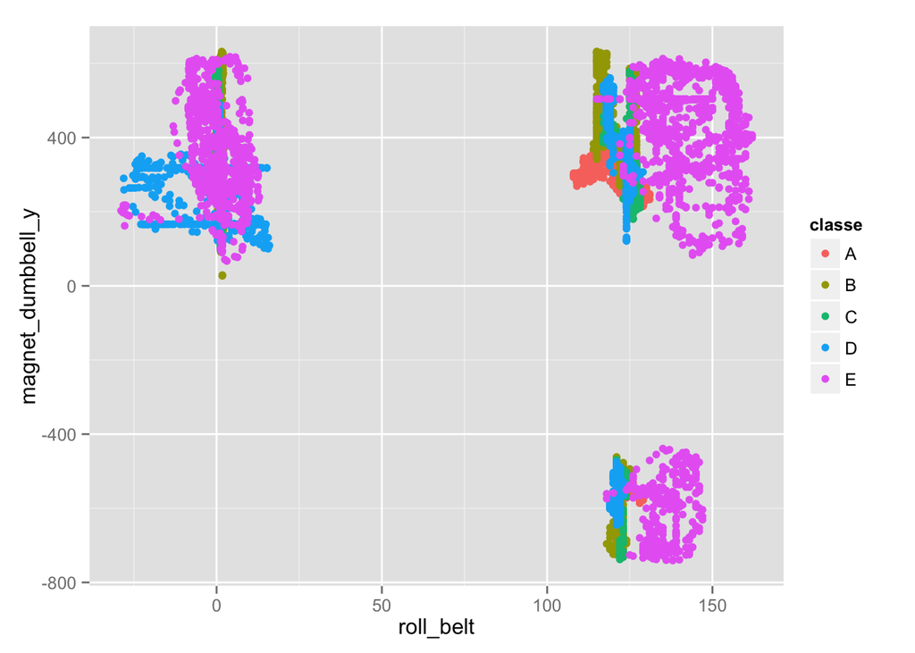

```r
qplot(roll_belt, magnet_dumbbell_y, colour=classe, data=myTraining)
```

This graph suggests that we could probably categorize the data into groups based on roll_belt values.

Incidentally, a quick tree classifier selects roll_belt as the first discriminant among all 53 covariates (which explains why we have eliminated yaw_belt instead of roll_belt, and not the opposite: it is a more important covariate).

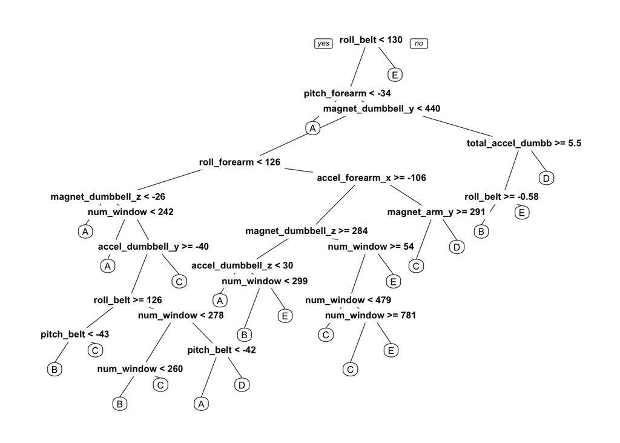

```r
library(rpart.plot)
fitModel <- rpart(classe~., data=myTraining, method="class")
prp(fitModel)
```

However, we will not investigate tree classifiers further as the Random Forest algorithm will prove very satisfactory.

## *Building Model*

We are now ready to create our model. We are using a Random Forest algorithm, using the train() function from the caret package. We are using 9 variables out of the 53 as model parameters. These variables were among the most significant variables generated by an initial Random Forest algorithm, and are roll_belt, num_window, pitch_belt, magnet_dumbbell_y, magnet_dumbbell_z, pitch_forearm, accel_dumbbell_y, roll_arm, and roll_forearm. These variable are relatively independent as the maximum correlation among them is 50.57%. We are using a 2-fold cross-validation control. This is the simplest k-fold cross-validation possible and it will give a reduced computation time. Because the data set is large, using a small number of folds is justified.

```r
set.seed(3141592)
fitModel <- train(classe~roll_belt+num_window+pitch_belt+magnet_dumbbell_y+magnet_dumbbell_z+pitch_forearm+accel_dumbbell_y+roll_arm+roll_forearm,
                  data=myTraining,
                  method="rf",
                  trControl=trainControl(method="cv",number=2),
                  prox=TRUE,
                  verbose=TRUE,
                  allowParallel=TRUE)
```

```r
saveRDS(fitModel, "modelRF.Rds")
fitModel <- readRDS("modelRF.Rds")
```

## *Determining the accuracy of the model*

We can use confusionMatrix() function applied on myTesting (the test set) to get an idea of the accuracy:

```r
predictions <- predict(fitModel, newdata=myTesting)
confusionMat <- confusionMatrix(predictions, myTesting$classe)
confusionMat
```

```
## Confusion Matrix and Statistics
##
##           Reference
## Prediction    A    B    C    D    E
##          A 2231    0    0    0    0
##          B    1 1517    1    0    2
##          C    0    0 1367    6    1
##          D    0    1    0 1280    4
##          E    0    0    0    0 1435
##
## Overall Statistics
##
##                Accuracy : 0.998
##                  95% CI : (0.9967, 0.9988)
##     No Information Rate : 0.2845
##     P-Value [Acc > NIR] : < 2.2e-16
##
##                   Kappa : 0.9974
##  Mcnemar's Test P-Value : NA
##
## Statistics by Class:
##
##                      Class: A Class: B Class: C Class: D Class: E
## Sensitivity            0.9996   0.9993   0.9993   0.9953   0.9951
## Specificity            1.0000   0.9994   0.9989   0.9992   1.0000
## Pos Pred Value         1.0000   0.9974   0.9949   0.9961   1.0000
## Neg Pred Value         0.9998   0.9998   0.9998   0.9991   0.9989
## Prevalence             0.2845   0.1935   0.1744   0.1639   0.1838
## Detection Rate         0.2843   0.1933   0.1742   0.1631   0.1829
## Detection Prevalence   0.2843   0.1939   0.1751   0.1638   0.1829
## Balanced Accuracy      0.9998   0.9994   0.9991   0.9973   0.9976
```

## *Estimating of the out-of-sample error rate*

```r
missClass = function(values, predicted) {
  sum(predicted != values) / length(values)
}
OOS_errRate = missClass(myTesting$classe, predictions)
OOS_errRate
```

```
## [1] 0.002039256
```

We can now answer Coursera challenge and predict the 20 observations in testing (recall that testing corresponds to the data set pml-testing.csv)

## *Coursera Submission*

We predict the classification of the 20 observations of the testing data set for Coursera Course Project: Submission page.

```r
predictions <- predict(fitModel, newdata=testing)
testing$classe <- predictions
```

We create one .CSV file with all the results, presented in two columns (named problem_id and classe) and 20 rows of data:

```r
submit <- data.frame(problem_id = testing$problem_id, classe = predictions)
write.csv(submit, file = "coursera-submission.csv", row.names = FALSE)
```

And we create twenty .TXT file that we will upload one by one in the Coursera website (the 20 files created are called problem_1.txt to problem_20.txt):

```r
answers = testing$classe
write_files = function(x){
  n = length(x)
  for(i in 1:n){
    filename = paste0("problem_",i,".txt")
    write.table(x[i], file=filename, quote=FALSE, row.names=FALSE, col.names=FALSE)
  }
}
write_files(answers)
```

## *Conclusion*

In this assignment, we accurately predicted the classification of 20 observations using a Random Forest algorithm trained on a subset of data using less than 20% of the covariates.

Either the 6 participants for whom we have data were extraordinarily obedient (for more than 19 thousand observations, a strong performance! This however might be explained by the highly controlled conditions of the data collection), or the data was somehow doctored for this class, or additional testing needs to be performed on other different participants, or Fitbit really works!

It may be interesting to apply the fitModel tree from the Random Forest algorithm obtained in this paper (without any re-calibration) to a completely new set of participants, to complement and validate the analysis.